# Cyclistics, Chicago 2024

marely

# Preparación de Datos

**Paso 1.** Instalación y carga del paquete `Tidyverse`

```r
if (!requireNamespace("tidyverse", quietly = TRUE))
  install.packages("tidyverse")
library(tidyverse)
```

**Paso 2.** Función para construir rutas.

```r
construir_ruta <- function(...){
  return(file.path(getwd(), ...))
}
```

**Paso 3.** Obtener las rutas de datos y datos de origen (data-meses)

```r
ruta_datos <- construir_ruta("data")
ruta_datos_de_origen <- construir_ruta("data", "data-meses")
```

**Paso 4.** Cargar y mostrar la lista de archivos csv correspondiente a los datos mensuales del proyecto.

```r
archivos_csv <- list.files(path = ruta_datos_de_origen, pattern = "\\.csv$", full.names = FALSE, recursive = TRUE)
print(archivos_csv)
```

**Paso 5.** Iterar sobre los archivos csv para visualizar las columnas.

```r
for (archivo in archivos_csv) {
  tryCatch({
    datos <- read.csv(file.path(ruta_datos_de_origen, archivo))
    print(paste('NOMBRE ARCHIVO: ', archivo))
    print(colnames(datos))
    str(datos)
    cat("\n")
  }, error = function(e) {
    message("Error leyendo archivo: ", archivo, "\n", e)
  })
}
```

**Paso 6.** Leer y combinar todos los archivos en un único dataframe.

```r
dataframe_combinado <- archivos_csv %>%
  map_df(~ read_csv(file.path(ruta_datos_de_origen, .))) # Combina automáticamente todos los datos
str(dataframe_combinado)
head(dataframe_combinado)
```

**Paso 7.** Exportar el dataframe a csv.

```r
write.csv(dataframe_combinado, file.path(ruta_datos, "2024-tripdata.csv"), row.names = FALSE)
```

# Limpieza de Datos

**Paso 1.** Instalar y cargar paquete `Lubridate`

```r
install.packages('lubridate')
library(lubridate)
```

**Paso 2.** Importar nuevas data y visualizar resumen de datos

```r
data <- read_csv(file.path(ruta_datos, '2024-tripdata.csv'))
head(data)
summary(data)
str(data)
glimpse(data)
```

**Paso 3.** Eliminar columnas innecesarias

```r
data <- data %>%
  select(-c('start_lat', 'start_lng', 'end_lat', 'end_lng'))
glimpse(data)
```

**Paso 4.** Renombrar las columnas

```r
tripdata_rename <- rename(data,
                          id_recorrido = ride_id,
                          tipo_bicicleta = rideable_type,
                          inicio_recorrido = started_at,
                          final_recorrido = ended_at,
                          estacion_inicial = start_station_name,
                          estacion_final = end_station_name,
                          id_estacion_inicial = start_station_id,
                          id_estacion_final = end_station_id,
                          tipo_cliente = member_casual)
glimpse(tripdata_rename)
```

**Paso 5.** Eliminar registros duplicados

```r
tripdata_rename <- tripdata_rename %>%  distinct()
```

**Paso 6.** Identificar tipo de usuarios y tipos de bicicletas

```r
tripdata_rename %>%
  group_by(tipo_bicicleta,tipo_cliente) %>%
  summarize(n())
```

**Paso 7.** Mutar la dataframe:

- Crear nuevas columnas: mes y dia_semana.
- Renombrar los timpos de clientes y tipos de bicicletas.
- Mostrar resultado.

```r
tripdata_new <- tripdata_rename %>%
  mutate(tiempo_recorrido = as.numeric(difftime(final_recorrido, inicio_recorrido, units = 'mins')),
         mes = format(as.Date(inicio_recorrido), "%B"),
         dia_semana = weekdays(as.Date(inicio_recorrido)),
         tipo_cliente = recode(tipo_cliente,
                               "member" = 'suscriptor',
                               "casual" = 'cliente'),
         tipo_bicicleta = recode(tipo_bicicleta,
                                 'classic_bike' = 'bicicleta clasica',
                                 'electric_bike' = 'bicicleta electrica',
                                 'electric_scooter' = 'scooter electrico'))
glimpse(tripdata_new)
head(tripdata_new)
```

**Paso 8.** Contar valores inferiores a cero en la columna `tiempo_recorrido`

```r
valores_negativos <- sum(tripdata_new$tiempo_recorrido < 0, na.rm = TRUE)
print(paste("Valores menores a 0 en tiempo_recorrido:", valores_negativos))
```

**Paso 9.** Fitrar recorrido con valores superiores a cero.

```r
tripdata_new <- tripdata_new %>%
  filter(tiempo_recorrido > 0)
```

**Paso 10.** Tratar valores nulos

1. Mostrar valores nulos, cantidad y porcentaje por columnas.

```r
    colSums(is.na(tripdata_new))
    porcentaje_nulos <- sapply(tripdata_new[, c("id_estacion_inicial", "estacion_inicial", "id_estacion_final", "estacion_final")], function(x) mean(is.na(x)) * 100)
    print(porcentaje_nulos)
```

2. Reemplazar valores nulos.

```r
    tripdata_new <- tripdata_new %>%
      replace_na(list(
        estacion_inicial = "Desconocido",
        id_estacion_inicial = "Desconocido",
        estacion_final = "Desconocido",
        id_estacion_final = "Desconocido"
      ))
```

**Paso 11.** Formatear columnas tipo caracter

```r
tripdata_new <- tripdata_new %>%
  mutate(
    across(where(is.character), ~ str_trim(.)),       # Eliminar espacios en blanco
    estacion_inicial = str_to_title(estacion_inicial),  # Inicial mayúscula
    estacion_final = str_to_title(estacion_final)     # Igual para final
  )
head(tripdata_new)
```

**Paso 12.** Manejo de columnas en conflicto

1. Agrupar las columnas con datos en conflicto por incosistencia de datos y contar las ocurrencias.

```r
    datos_conflictos_inicial <- tripdata_new %>%
      group_by(id_estacion_inicial, estacion_inicial) %>%
      summarize(conteo = n(), .groups = "drop") %>%
      ungroup() %>% group_by(id_estacion_inicial) %>%
      filter(n() > 1)
    print(datos_conflictos_inicial)
```

2. Eliminar columnas para evitar inconsistencia de datos y sesgo.

```r
tripdata_new <- tripdata_new %>%
  select(-c('id_estacion_inicial','estacion_inicial','id_estacion_final','estacion_final'))
glimpse(tripdata_new)
```

**Paso 13.** Exportar dataframe limpio a csv.

```r
write.csv(tripdata_new, file.path(ruta_datos, "2024-tripdata-clean.csv"), row.names = FALSE)
```

# Análisis y Visualización de Datos

**Paso 1.** Cargar los paquetes necesarios.

```r
install.packages('scales')
library(scales)
library(ggplot2)
```

**Paso 2.** Importar datos limpios.

```r
data_clean <- read_csv(file.path(ruta_datos, '2024-tripdata-clean.csv'))
glimpse(data_clean)
head(data_clean)
```

**Paso 3.** Análisis descriptivos de tiempo de recorrido

```r
summary(data_clean$tiempo_recorrido)
```

**Paso 4.** Análisis comparativo entre clientes y suscriptores

```r
aggregate(data_clean$tiempo_recorrido ~ data_clean$tipo_cliente, FUN = mean)
aggregate(data_clean$tiempo_recorrido ~ data_clean$tipo_cliente, FUN = median)
aggregate(data_clean$tiempo_recorrido ~ data_clean$tipo_cliente, FUN = max)
aggregate(data_clean$tiempo_recorrido ~ data_clean$tipo_cliente, FUN = min)
```

**Paso 5.** Definir días de la semana y meses del año

```r
data_clean$mes <- ordered(data_clean$mes, levels=c('enero','febrero','marzo','abril','mayo','junio','julio','agosto','septiembre','octubre','noviembre','diciembre'))
data_clean$dia_semana <- ordered(data_clean$dia_semana, levels=c("lunes", "martes", "miércoles", "jueves", "viernes", "sábado","domingo"))
```

**Paso 6.** Vectores ordenados

1. Días de la semana ordenados de lunes a domingo

```r
  dias_semana_ordenados <- c("lunes", "martes", "miércoles", "jueves", "viernes", "sábado", "domingo")
```

2. Meses del año, ordenados de enero a diciembre.

```r
  meses_ordenados <- c("enero", "febrero", "marzo", "abril", "mayo", "junio",
                         "julio", "agosto", "septiembre", "octubre", "noviembre", "diciembre")
```

**Paso 7.** Definir una paleta de colores específica para cada tipo de cliente

```r
colores_clientes <- c("suscriptor" = "#1b9e77", "cliente" = "#5F02D9")
```

**Paso 8.** Visualizar tiempo promedio diario entre clientes y suscriptores

```r
aggregate(data_clean$tiempo_recorrido ~ data_clean$tipo_cliente + data_clean$dia_semana, FUN = mean)
```

**Paso 9.** Visualizaciones Periodo Mensual

1. **Resumen:** cantidad de recorridos y tiempo promedio de recorridos agrupados por tipo de cliente y mes

```r
# Verificar los valores únicos en la columna 'tipo_cliente'
unique(data_clean$tipo_cliente)
# Resumir datos por mes
data_resumen_mes <- data_clean %>%
  mutate(mes = factor(mes, levels = meses_ordenados)) %>%
  group_by(tipo_cliente, mes) %>%
  summarise(
    cantidad_recorridos = n(),
    tiempo_promedio = mean(tiempo_recorrido, na.rm = TRUE),
    .groups = "drop"
  )
```

2. **Visualización:** Tendencia de recorridos mensuales por tipo de cliente

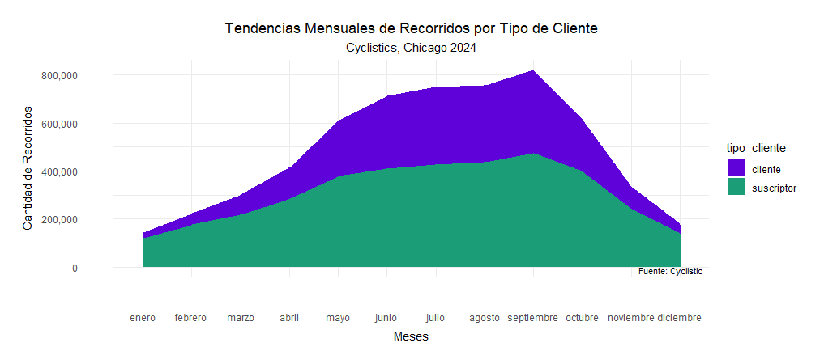

```r
# Visualización: Gráfico de área por tendencias mensuales de recorridos
ggplot(data_resumen_mes,aes(x = mes, y = cantidad_recorridos, group = tipo_cliente, fill = tipo_cliente)) +
  geom_area(position = "stack") +
  scale_fill_manual(values = colores_clientes) + # Aplicar la paleta de colores específica
  scale_y_continuous(labels = comma) + # Cambia el formato del eje Y
  labs(title = "Tendencias Mensuales de Recorridos por Tipo de Cliente",
       subtitle = "Cyclistics, Chicago 2024", # Subtítulo
       x = "Meses",
       y = "Cantidad de Recorridos") +
  theme_minimal() +
  theme(
    plot.title = element_text(hjust = 0.5),  # Alinea el título a la derecha
    plot.subtitle = element_text(hjust = 0.5), # Alinea el subtítulo a la derecha
    axis.text.x = element_text(margin = margin(t = 30, b=5)), # Añadir margen superior a las etiquetas del eje X
    axis.text.y = element_text(margin = margin(r = 30, l=5)), # Añadir margen derecho a las etiquetas del eje Y
    plot.margin = margin(t = 20, b = 20, l = 20, r = 20) # Añadir margen superior para subir el título y subtítulo
  ) +
  annotate("text", x = Inf, y = -Inf, label = "Fuente: Cyclistic", hjust = 1.1, vjust = -0.5, size = 3)
```

3. **Visualización:** Tiempo medio recorrido mensual por tipo de cliente

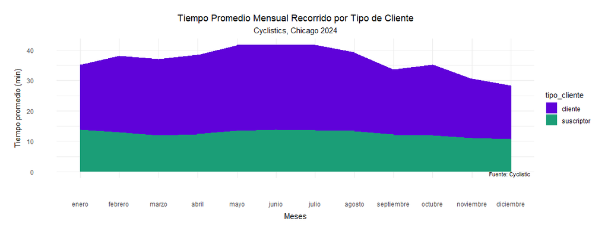

```r
ggplot(data_resumen_mes,aes(x = mes, y = tiempo_promedio, group = tipo_cliente, fill = tipo_cliente)) +
  geom_area(position = "stack") +
  scale_fill_manual(values = colores_clientes) + # Aplicar la paleta de colores específica
  scale_y_continuous(labels = comma) + # Cambia el formato del eje Y
  labs(title = "Tiempo Promedio Mensual Recorrido por Tipo de Cliente",
       subtitle = "Cyclistics, Chicago 2024", # Subtítulo
       x = "Meses",
       y = "Tiempo promedio (min)") +
  theme_minimal() +
  theme(
    plot.title = element_text(hjust = 0.5),  # Alinea el título a la derecha
    plot.subtitle = element_text(hjust = 0.5), # Alinea el subtítulo a la derecha
    axis.text.x = element_text(margin = margin(t = 30, b=5)), # Añadir margen superior a las etiquetas del eje X
    axis.text.y = element_text(margin = margin(r = 30, l=5)), # Añadir margen derecho a las etiquetas del eje Y
    plot.margin = margin(t = 20, b = 20, l = 20, r = 20) # Añadir margen superior para subir el título y subtítulo
  ) +
  annotate("text", x = Inf, y = -Inf, label = "Fuente: Cyclistic", hjust = 1.1, vjust = -0.5, size = 3)
```

Paso 10. Visualizaciones Periodo Diario

1. **Resumen:** cantidad de recorridos y tiempo medio agrupados por tipo de cliente y dia de la semana.

```r
  # Resumir datos para dias de la semana
  data_resumen_semana <- data_clean %>%
    mutate(dia_semana = factor(dia_semana, levels = dias_semana_ordenados),
           hora_inicio = hour(inicio_recorrido),
           hora_final = hour(final_recorrido)) %>%
    group_by(tipo_cliente, dia_semana) %>%
    summarise(
      cantidad_recorridos = n(),
      tiempo_promedio = mean(tiempo_recorrido, na.rm = TRUE),
      .groups = "drop"
    )
```

2. **Visualización:** “Total de Recorridos Diarios por Tipo de Cliente”

[figure not shown]

```r
# Visualización: Número de recorridos
ggplot(data_resumen_semana, aes(x = dia_semana, y = cantidad_recorridos, fill = tipo_cliente)) +
  geom_col(position = "dodge") +
  scale_fill_manual(values = colores_clientes) + # Aplicar la paleta de colores específica
  scale_y_continuous(labels = comma) + # Cambia el formato del eje Y
  labs(
    title = "Total de Recorridos Diarios por Tipo de Cliente",
    subtitle = "Cyclistics, Chicago 2024",
    x = "Día de la Semana", y = "Número de Recorridos"
  ) +
  theme_minimal() +
  theme(
    plot.title = element_text(hjust = 0.5), # Centra el título
    plot.subtitle = element_text(hjust = 0.5), # Centra el subtítulo
    axis.text.x = element_text(margin = margin(t = 30, b=5)), # Añadir margen superior a las etiquetas del eje X
    axis.text.y = element_text(margin = margin(r = 30, l=5)), # Añadir margen derecho a las etiquetas del eje Y
    plot.margin = margin(t = 20, b = 20, l = 20, r = 20) # Añadir margen superior para subir el título y subtítulo
    ) +
  annotate("text", x = Inf, y = -Inf, label = "Fuente: Cyclistic", hjust = 1.1, vjust = -0.5, size = 3)
```

3. **Visualización:** ” Tiempo Medio Diario por Tipo de Cliente”

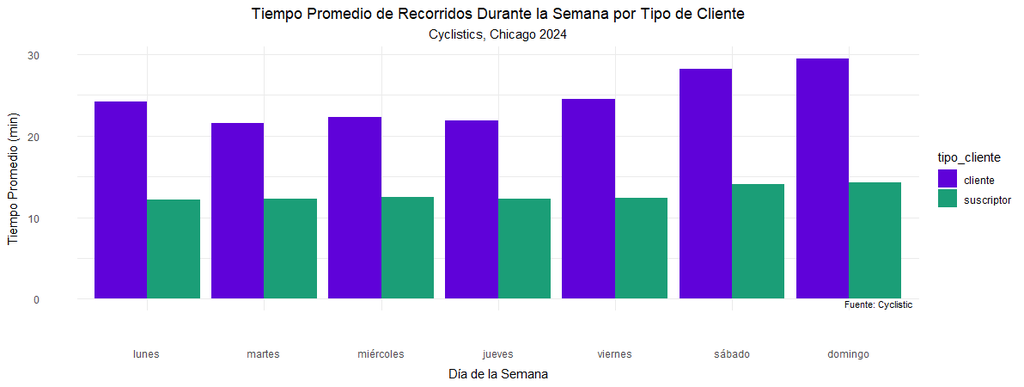

```r
# Visualización: Tiempo promedio  de recorridos por tipo de cliente en dias de la semana
ggplot(data_resumen_semana, aes(x = dia_semana, y = tiempo_promedio, fill = tipo_cliente)) +
  geom_col(position = "dodge") +
  scale_fill_manual(values = colores_clientes) + # Aplicar la paleta de colores específica
  scale_y_continuous(labels = comma) + # Cambia el formato del eje Y
  labs(
    title = "Tiempo Promedio de Recorridos Durante la Semana por Tipo de Cliente",
    subtitle = "Cyclistics, Chicago 2024",
    x = "Día de la Semana", y = "Tiempo Promedio (min)"
  ) +
  theme_minimal() +
  theme(
    plot.title = element_text(hjust = 0.5), # Centra el título
    plot.subtitle = element_text(hjust = 0.5), # Centra el subtítulo
    axis.text.x = element_text(margin = margin(t = 30, b=5)), # Añadir margen superior a las etiquetas del eje X
    axis.text.y = element_text(margin = margin(r = 30, l=5)), # Añadir margen derecho a las etiquetas del eje Y
  ) +
  annotate("text", x = Inf, y = -Inf, label = "Fuente: Cyclistic", hjust = 1.1, vjust = -0.5, size = 3)
```